# Ford GoBike Dataset Analysis

## by Janani R

## Investigation Overview

Among other features such as age, gender and locations, the primary feature of interest was trip duration.

## Dataset Overview

Each trip is anonymized and includes:

1. Trip Duration (seconds)
2. Start Time and Date
3. End Time and Date
4. Start Station ID
5. Start Station Name
6. Start Station Latitude
7. Start Station Longitude
8. End Station ID
9. End Station Name
10. End Station Latitude
11. End Station Longitude
12. Bike ID
13. User Type (Subscriber or Customer – “Subscriber” = Member or “Customer” = Casual)
14. Member Year of Birth
15. Member Gender

There were 519700 records in which high amount of variation existed with respect to duration with a standard deviation of 3444. But 75% of the values lied below 1000 which was considered while trimming outliers.

## Univariate Exploration of Trip Duration

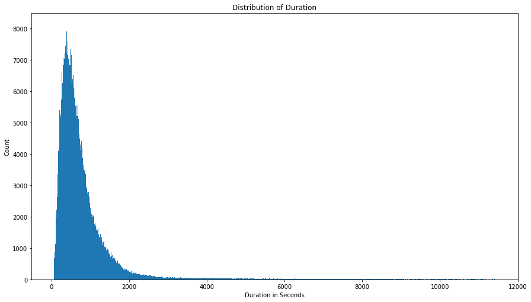

```python
# Removing the outliers
bikes = bikes[(np.abs(stats.zscore(bikes.duration_sec)) < 3)]

# Visualization
graph = bikes.duration_sec
plt.figure(figsize=[14.70, 8.27])
plt.hist(graph,bins=1000);
plt.title("Distribution of Duration")
plt.xlabel('Duration in Seconds')
plt.ylabel('Count');
```

## The effect of User Type on Trip Duration

This visualization represents the relationship between User Type and Trip Duration, indicating that regular users take lesser time to complete rides.

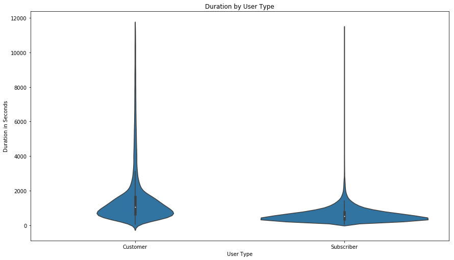

```python
# User Type and Duration
plt.figure(figsize=[14.70, 8.27])
sns.violinplot(data=bikes,x='user_type',y='duration_sec', color=base_color);
plt.title("Duration by User Type")
plt.xlabel('User Type')
plt.ylabel('Duration in Seconds');
```

## Duration vs Start Hour (with respect to top start-end locations)

Considering only the top locations in which trips most commonly start and end, I plotted the relationship between duration and start hour overall and then per start to end location. Both reflected that more time was taken during daytime, presumably due to higher traffic.

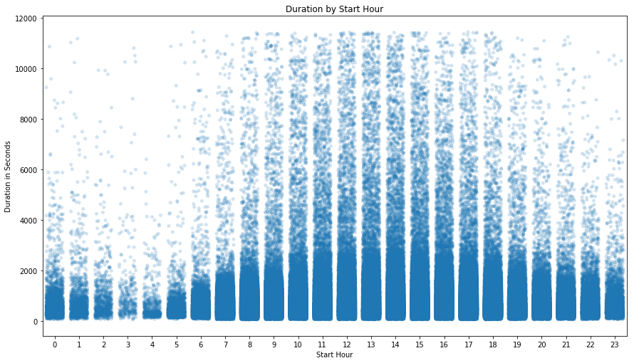

```python
# Duration vs Start Hour
plt.figure(figsize=[14.70, 8.27])
sns.stripplot(data = bikes, x='start_t_hour', y='duration_sec', alpha=0.2, jitter=0.35, color=base_color);
plt.xlabel('Start Hour')
plt.ylabel('Duration in Seconds')
plt.title("Duration by Start Hour");
```

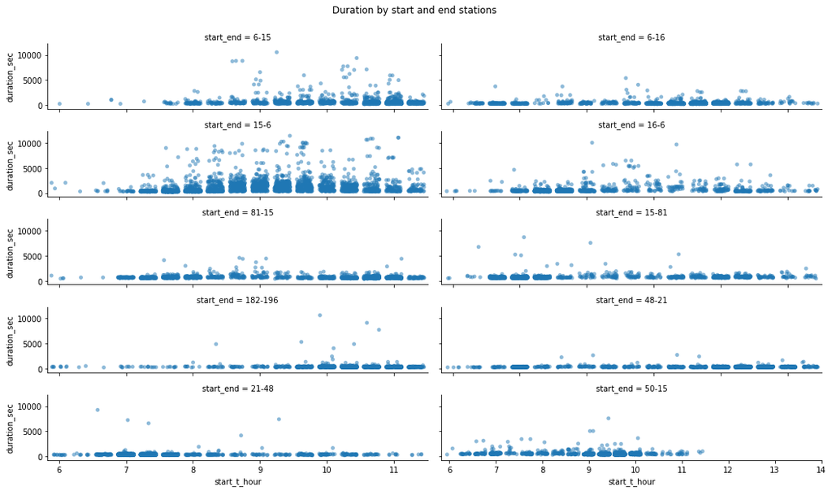

```python
# Create key to capture start and end locations
bikes['start_end'] = bikes.apply(lambda x:str(x['start_station_id'])+'-'+str(x['end_station_id']),axis=1)

# Find commonly trafficked start and end locations
top_locations = list(bikes.groupby(['start_end'])['trip_id'].count().sort_values(ascending=False)[:10].index.values)

# Plot the trips only for such locations
tripdata_by_location = bikes[bikes.start_end.isin(top_locations)]
g = sns.FacetGrid(data=tripdata_by_location, col='start_end',col_wrap=2,height=(8.27/5),aspect=(14.7/2)/(8.27/5))
g.map(sns.stripplot,'start_t_hour', 'duration_sec',alpha=0.5,jitter=0.35);
plt.suptitle("Duration by start and end stations", y = 1.04)
plt.tight_layout()
plt.xticks(np.arange(0,25,3));
```